# Project_Full_Code_Notebook_EasyVisa

[figure not shown]

Data Science and Business Analytics

Ensemble Techniques and Model Tuning

[figure not shown]

Visa Approval Facilitation

# **Problem Statement**

## Context

Business communities in the United States are facing high demand for human resources, but one of the constant challenges is identifying and attracting the right talent, which is perhaps the most important element in remaining competitive. Companies in the United States look for hard-working, talented, and qualified individuals both locally as well as abroad.

The Immigration and Nationality Act (INA) of the US permits foreign workers to come to the United States to work on either a temporary or permanent basis. The act also protects US workers against adverse impacts on their wages or working conditions by ensuring US employers' compliance with statutory requirements when they hire foreign workers to fill workforce shortages. The immigration programs are administered by the Office of Foreign Labor Certification (OFLC).

OFLC processes job certification applications for employers seeking to bring foreign workers into the United States and grants certifications in those cases where employers can demonstrate that there are not sufficient US workers available to perform the work at wages that meet or exceed the wage paid for the occupation in the area of intended employment.

## Objective

In FY 2016, the OFLC processed 775,979 employer applications for 1,699,957 positions for temporary and permanent labor certifications. This was a nine percent increase in the overall number of processed applications from the previous year. The process of reviewing every case is becoming a tedious task as the number of applicants is increasing every year.

The increasing number of applicants every year calls for a Machine Learning based solution that can help in shortlisting the candidates having higher chances of VISA approval. OFLC has hired the firm EasyVisa for data-driven solutions. You as a data scientist at EasyVisa have to analyze the data provided and, with the help of a classification model:

- Facilitate the process of visa approvals.
- Recommend a suitable profile for the applicants for whom the visa should be certified or denied based on the drivers that significantly influence the case status.

## Data Description

The data contains the different attributes of employee and the employer. The detailed data dictionary is given below.

- case_id: ID of each visa application
- continent: Information of continent the employee
- education_of_employee: Information of education of the employee
- has_job_experience: Does the employee has any job experience? Y= Yes; N = No
- requires_job_training: Does the employee require any job training? Y = Yes; N = No
- no_of_employees: Number of employees in the employer's company
- yr_of_estab: Year in which the employer's company was established
- region_of_employment: Information of foreign worker's intended region of employment in the US.
- prevailing_wage: Average wage paid to similarly employed workers in a specific occupation in the area of intended employment. The purpose of the prevailing wage is to ensure that the foreign worker is not underpaid compared to other workers offering the same or similar service in the same area of employment.
- unit_of_wage: Unit of prevailing wage. Values include Hourly, Weekly, Monthly, and Yearly.
- full_time_position: Is the position of work full-time? Y = Full Time Position; N = Part Time Position
- case_status: Flag indicating if the Visa was certified or denied

## Note: This is a sample solution for the project. Projects will NOT be graded on the basis of how well the submission matches this sample solution. Projects will be graded on the basis of the rubric only.

# **Importing necessary libraries**

```python
# ===========================================
# GENERAL UTILITIES
# ===========================================
import warnings
warnings.filterwarnings('ignore')

import numpy as np
import pandas as pd

# ===========================================
# VISUALIZATION LIBRARIES
# ===========================================
import matplotlib.pyplot as plt
%matplotlib inline
import seaborn as sns

# ===========================================
# DATA PREPROCESSING + SPLITTING
# ===========================================
from sklearn.model_selection import train_test_split
from sklearn.impute import SimpleImputer
from sklearn.compose import ColumnTransformer
from sklearn.preprocessing import OneHotEncoder

# ===========================================
# CLASSIFIERS (Decision Trees + Ensembles)
# ===========================================
from sklearn.tree import DecisionTreeClassifier
from sklearn.ensemble import (
    RandomForestClassifier,
    BaggingClassifier,
    AdaBoostClassifier,
    GradientBoostingClassifier,
    StackingClassifier
)

# XGBoost
from xgboost import XGBClassifier

# ===========================================
# PIPELINES
# ===========================================
from sklearn.pipeline import Pipeline
from imblearn.pipeline import Pipeline as ImbPipeline  # for SMOTE + model in same pipeline


# ===========================================
# SAMPLING (SMOTE)
# ===========================================
from imblearn.over_sampling import SMOTE

# ===========================================
# MODEL EVALUATION METRICS
# ===========================================
from sklearn.metrics import (
    confusion_matrix,
    classification_report,
    accuracy_score,
    precision_score,
    recall_score,
    f1_score,
    roc_auc_score
)

# ===========================================
# HYPERPARAMETER TUNING
# ===========================================
from sklearn.model_selection import GridSearchCV, RandomizedSearchCV
```

```python
# Mount Google Drive to access project files stored in the Drive
from google.colab import drive
drive.mount('/content/drive')
```

# **Loading the dataset**

```python
# Load the EASYVISA dataset from Google Drive into a pandas DataFrame
EasyVisa = pd.read_csv('/content/drive/MyDrive/Colab Notebooks/UTA/Data Science/EasyVisa.csv')
```

```python
# copying data to another varaible to avoid any changes to original data
data = EasyVisa.copy()
```

# **Overview of the Dataset**

### Displaying the first and last 5 rows of the dataset

```python
data.head()
```

|  | case_id | continent | education_of_employee | has_job_experience | requires_job_training | no_of_employees | yr_of_estab | region_of_employment | prevailing_wage | unit_of_wage | full_time_position | case_status |
| --- | --- | --- | --- | --- | --- | --- | --- | --- | --- | --- | --- | --- |
| 0 | EZYV01 | Asia | High School | N | N | 14513 | 2007 | West | 592.2029 | Hour | Y | Denied |
| 1 | EZYV02 | Asia | Master's | Y | N | 2412 | 2002 | Northeast | 83425.6500 | Year | Y | Certified |
| 2 | EZYV03 | Asia | Bachelor's | N | Y | 44444 | 2008 | West | 122996.8600 | Year | Y | Denied |
| 3 | EZYV04 | Asia | Bachelor's | N | N | 98 | 1897 | West | 83434.0300 | Year | Y | Denied |
| 4 | EZYV05 | Africa | Master's | Y | N | 1082 | 2005 | South | 149907.3900 | Year | Y | Certified |

```python
data.tail()
```

|  | case_id | continent | education_of_employee | has_job_experience | requires_job_training | no_of_employees | yr_of_estab | region_of_employment | prevailing_wage | unit_of_wage | full_time_position | case_status |
| --- | --- | --- | --- | --- | --- | --- | --- | --- | --- | --- | --- | --- |
| 25475 | EZYV25476 | Asia | Bachelor's | Y | Y | 2601 | 2008 | South | 77092.57 | Year | Y | Certified |
| 25476 | EZYV25477 | Asia | High School | Y | N | 3274 | 2006 | Northeast | 279174.79 | Year | Y | Certified |
| 25477 | EZYV25478 | Asia | Master's | Y | N | 1121 | 1910 | South | 146298.85 | Year | N | Certified |
| 25478 | EZYV25479 | Asia | Master's | Y | Y | 1918 | 1887 | West | 86154.77 | Year | Y | Certified |
| 25479 | EZYV25480 | Asia | Bachelor's | Y | N | 3195 | 1960 | Midwest | 70876.91 | Year | Y | Certified |

### Understand the shape of the dataset.

```python
data.shape
```

```
(25480, 12)
```

- There are 25,480 observations and 12 columns in the dataset

### Check the data types of the columns for the dataset.

```python
data.info()
```

```
<class 'pandas.core.frame.DataFrame'>
RangeIndex: 25480 entries, 0 to 25479
Data columns (total 12 columns):
 #   Column                 Non-Null Count  Dtype
---  ------                 --------------  -----
 0   case_id                25480 non-null  object
 1   continent              25480 non-null  object
 2   education_of_employee  25480 non-null  object
 3   has_job_experience     25480 non-null  object
 4   requires_job_training  25480 non-null  object
 5   no_of_employees        25480 non-null  int64
 6   yr_of_estab            25480 non-null  int64
 7   region_of_employment   25480 non-null  object
 8   prevailing_wage        25480 non-null  float64
 9   unit_of_wage           25480 non-null  object
 10  full_time_position     25480 non-null  object
 11  case_status            25480 non-null  object
dtypes: float64(1), int64(2), object(9)
memory usage: 2.3+ MB
```

**Observations**

- There is a mixture of numeric and object data types.Some columns like has_job_experience, requires_job_training, full_time_position and case_status will need conversion.
- There are no missing values in the data.

### Summary of the dataset.

```python
data.describe().T
```

|  | count | mean | std | min | 25% | 50% | 75% | max |
| --- | --- | --- | --- | --- | --- | --- | --- | --- |
| no_of_employees | 25480.0 | 5667.043210 | 22877.928848 | -26.0000 | 1022.00 | 2109.00 | 3504.0000 | 602069.00 |
| yr_of_estab | 25480.0 | 1979.409929 | 42.366929 | 1800.0000 | 1976.00 | 1997.00 | 2005.0000 | 2016.00 |
| prevailing_wage | 25480.0 | 74455.814592 | 52815.942327 | 2.1367 | 34015.48 | 70308.21 | 107735.5125 | 319210.27 |

**Observations**

- no_of_employees: Shows a very wide range (-26 to 602,069) with a large standard deviation, indicating high variability in company sizes.
- yr_of_estab: Ranges from 1800 to 2016 with relatively lower spread, suggesting establishment years are more consistent across employers.
- prevailing_wage: Has a broad range (2.13 to 319,210.27) and high standard deviation, indicating substantial variation in wage levels.
- Outliers/Unusual Values: Negative employee counts (-26) and extremely low wages (e.g., 2.13) indicate unusual or potentially erroneous values in the dataset.

### Check unique values

```python
data.nunique()
```

|  | 0 |
| --- | --- |
| case_id | 25480 |
| continent | 6 |
| education_of_employee | 4 |
| has_job_experience | 2 |
| requires_job_training | 2 |
| no_of_employees | 7105 |
| yr_of_estab | 199 |
| region_of_employment | 5 |
| prevailing_wage | 25454 |
| unit_of_wage | 4 |
| full_time_position | 2 |
| case_status | 2 |

**dtype:** int64

**Observations**

- Case_ID column will be dropped since it is an identifier and not required for the model.
- has_job_experience, requires_job_training, full_time_position and case_status have only two unique values and will be converted to numeric for modeling
- continent, education_of_employee, region_of_employment, unit_of_wage do not hhave a lot of unique values and will be one-hot encoded later

```python
#drop case_id
data.drop("case_id", axis=1, inplace=True)
```

```python
#Check unique values in binary cols for mapping accuracy

binary_cols = [
    'has_job_experience',
    'requires_job_training',
    'full_time_position',
    'case_status'
]

for col in binary_cols:
    print(f"Unique values in '{col}':")
    print(data[col].unique())
    print("-" * 50)
```

```
Unique values in 'has_job_experience':
['N' 'Y']
--------------------------------------------------
Unique values in 'requires_job_training':
['N' 'Y']
--------------------------------------------------
Unique values in 'full_time_position':
['Y' 'N']
--------------------------------------------------
Unique values in 'case_status':
['Denied' 'Certified']
--------------------------------------------------
```

```python
# Convert Binary Columns to Numeric (0/1)

# Columns to convert
binary_cols = [
    'has_job_experience',
    'requires_job_training',
    'full_time_position',
    'case_status'
]

# Function to convert binary categorical columns to numeric (0/1)
def convert_binary_columns(df):
    binary_map = {
        'Y': 1,
        'N': 0,
        'Certified': 1,
        'Denied': 0
    }

    for col in binary_cols:
        df[col] = df[col].map(binary_map)

    return df

# Apply the conversion
data = convert_binary_columns(data)

# Confirm changes
data[binary_cols].head()
```

|  | has_job_experience | requires_job_training | full_time_position | case_status |
| --- | --- | --- | --- | --- |
| 0 | 0 | 0 | 1 | 0 |
| 1 | 1 | 0 | 1 | 1 |
| 2 | 0 | 1 | 1 | 0 |
| 3 | 0 | 0 | 1 | 0 |
| 4 | 1 | 0 | 1 | 1 |

# **Exploratory Data Analysis (EDA)**

- EDA is an important part of any project involving data.
- It is important to investigate and understand the data better before building a model with it.
- A few questions have been mentioned below which will help you approach the analysis in the right manner and generate insights from the data.
- A thorough analysis of the data, in addition to the questions mentioned below, should be done.

**Leading Questions**

1. What is the distribution of visa case statuses (certified vs. denied)?

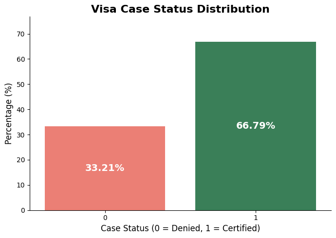

```python
# Calculate counts and percentages
status_counts = data['case_status'].value_counts().sort_index()
status_percent = (status_counts / len(data) * 100).round(2)

# Colors: Denied = red, Certified = green
colors = ["#FF6F61", "#2E8B57"]

plt.figure(figsize=(7,5))
ax = sns.barplot(
    x=status_percent.index,
    y=status_percent.values,
    palette=colors
)

# Add labels
for i, value in enumerate(status_percent.values):
    ax.text(
        i,
        value / 2,
        f"{value}%",
        ha='center',
        va='center',
        fontsize=14,
        fontweight='bold',
        color="white"
    )

# Style Axis and Tiles
plt.title("Visa Case Status Distribution", fontsize=16, weight='bold')
plt.xlabel("Case Status (0 = Denied, 1 = Certified)", fontsize=12)
plt.ylabel("Percentage (%)", fontsize=12)

# Remove extra visual noise
sns.despine()
plt.ylim(0, status_percent.max() + 10)
plt.tight_layout()
plt.show()
```

**Observations**

- Majority of visa applications in the dataset are Certified (66.79%), while 33.21% are Denied, indicating a moderate class imbalance with more approvals than denials.
2. How does the education level of employees impact visa approval rates?

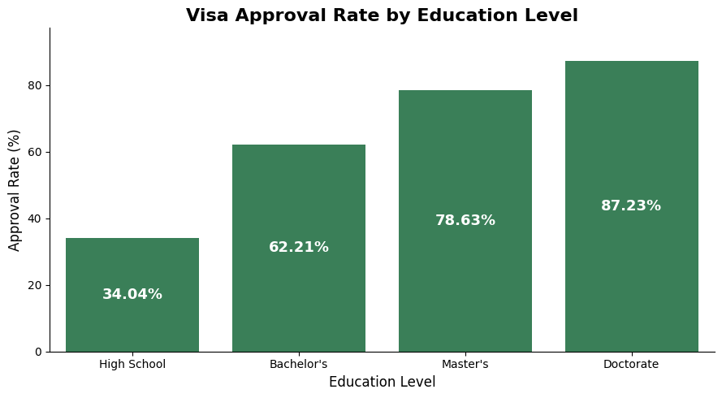

```python
# Calculate approval rate (% Certified) by education level
edu_approval = (
    data.groupby("education_of_employee")["case_status"]
    .mean()
    .sort_values()
    * 100
).round(2)

#set color
color = "#2E8B57"

plt.figure(figsize=(9, 5))
ax = sns.barplot(
    x=edu_approval.index,
    y=edu_approval.values,
    color=color
)

# Add labels inside bars
for i, value in enumerate(edu_approval.values):
    ax.text(
        i,
        value / 2,
        f"{value}%",
        ha='center',
        va='center',
        fontsize=13,
        fontweight='bold',
        color="white"
    )

# Titles & labels
plt.title("Visa Approval Rate by Education Level", fontsize=16, weight='bold')
plt.xlabel("Education Level", fontsize=12)
plt.ylabel("Approval Rate (%)", fontsize=12)

# Clean style
sns.despine()
plt.ylim(0, edu_approval.max() + 10)
plt.tight_layout()
plt.show()
```

**Observations**

- Visa approval rates increase steadily with higher education levels. Applicants with a High School education have the lowest approval rate at 34.04%, while approval rates rise to 62.21% for Bachelor’s, 78.63% for Master’s, and reach the highest level of 87.23% for Doctorate holders. This indicates a clear positive relationship between education level and the likelihood of visa certification.
3. Is there a significant difference in visa approval rates between employees with and without prior job experience?

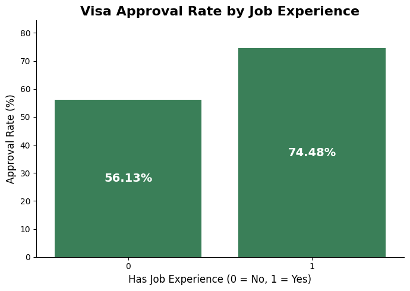

```python
# Calculate approval rate (% Certified) by job experience
exp_approval = (
    data.groupby("has_job_experience")["case_status"]
    .mean()
    .sort_index()
    * 100
).round(2)

# Colors: single clean color (same as previous)
color = "#2E8B57"

plt.figure(figsize=(7,5))
ax = sns.barplot(
    x=exp_approval.index,
    y=exp_approval.values,
    color=color
)

# Add centered labels
for i, value in enumerate(exp_approval.values):
    ax.text(
        i,
        value / 2,
        f"{value}%",
        ha='center',
        va='center',
        fontsize=14,
        fontweight='bold',
        color="white"
    )

# Titles and axis labels
plt.title("Visa Approval Rate by Job Experience", fontsize=16, weight='bold')
plt.xlabel("Has Job Experience (0 = No, 1 = Yes)", fontsize=12)
plt.ylabel("Approval Rate (%)", fontsize=12)

sns.despine()
plt.ylim(0, exp_approval.max() + 10)
plt.tight_layout()
plt.show()
```

**Observations**

- Visa approval rates are notably higher for applicants with prior job experience. Applicants without job experience have an approval rate of 56.13%, while those with job experience have a much higher approval rate of 74.48%.
4. How does the prevailing wage affect visa approval? Do higher wages lead to higher chances of approval?

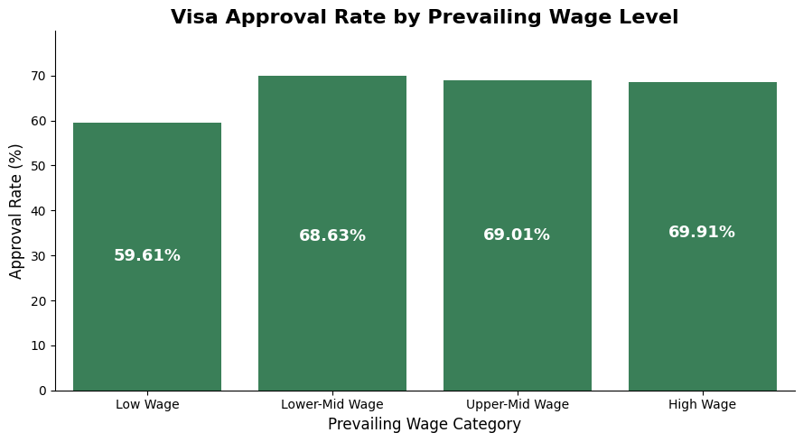

```python
# Create wage bins (quartiles)
data['wage_bin'] = pd.qcut(
    data['prevailing_wage'],
    q=4,
    labels=['Low Wage', 'Lower-Mid Wage', 'Upper-Mid Wage', 'High Wage']
)

# Compute approval rate per wage bin
wage_approval = (
    data.groupby('wage_bin')['case_status']
    .mean()
    .sort_values()
    * 100
).round(2)

# Clean bar plot
plt.figure(figsize=(9,5))
ax = sns.barplot(
    x=wage_approval.index,
    y=wage_approval.values,
    color="#2E8B57"
)

# Add centered % labels
for i, value in enumerate(wage_approval.values):
    ax.text(
        i,
        value / 2,
        f"{value}%",
        ha='center',
        va='center',
        fontsize=13,
        fontweight='bold',
        color="white"
    )

# Titles and styling
plt.title("Visa Approval Rate by Prevailing Wage Level", fontsize=16, weight='bold')
plt.xlabel("Prevailing Wage Category", fontsize=12)
plt.ylabel("Approval Rate (%)", fontsize=12)

sns.despine()
plt.ylim(0, wage_approval.max() + 10)
plt.tight_layout()
plt.show()
```

**Observations**

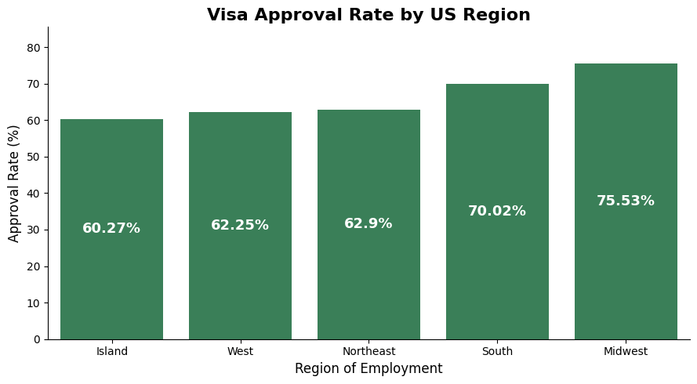

```python
# Compute approval rate per region
region_approval = (
    data.groupby("region_of_employment")["case_status"]
    .mean()
    .sort_values()
    * 100
).round(2)

# Plot
plt.figure(figsize=(9,5))
ax = sns.barplot(
    x=region_approval.index,
    y=region_approval.values,
    color="#2E8B57"
)

# Add centered labels
for i, value in enumerate(region_approval.values):
    ax.text(
        i,
        value / 2,
        f"{value}%",
        ha="center",
        va="center",
        fontsize=13,
        fontweight="bold",
        color="white"
    )

plt.title("Visa Approval Rate by US Region", fontsize=16, weight="bold")
plt.xlabel("Region of Employment", fontsize=12)
plt.ylabel("Approval Rate (%)", fontsize=12)

sns.despine()
plt.ylim(0, region_approval.max() + 10)
plt.tight_layout()
plt.show()
```

**Observations**

- Visa approval rates vary noticeably across US regions. The Midwest has the highest approval rate at 75.53%, followed by the South at 70.02%.
- The Northeast (62.9%), West (62.25%), and Island regions (60.27%) show lower approval percentages in comparison.
6. How does the number of employees in a company influence visa approval? Do larger companies have a higher approval rate?

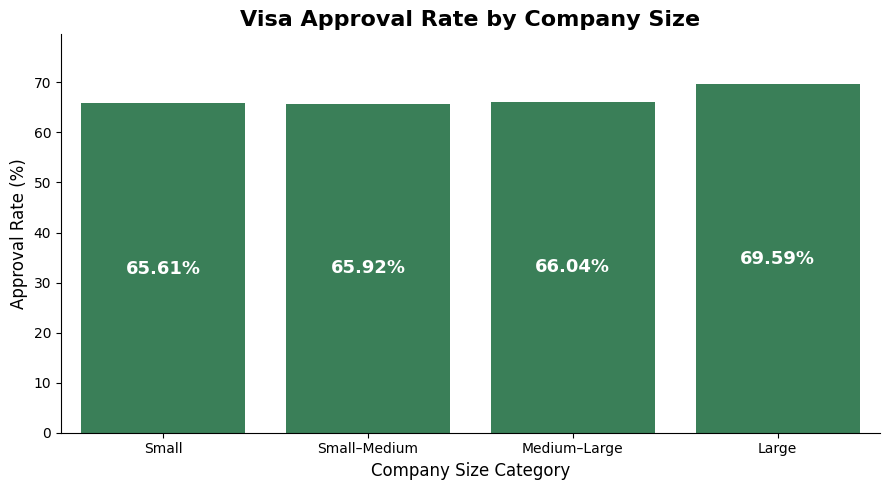

```python
# Create employee-size bins using quartiles
data['employee_bin'] = pd.qcut(
    data['no_of_employees'],
    q=4,
    labels=['Small', 'Small–Medium', 'Medium–Large', 'Large']
)

# Compute approval rate per company size bin
employee_approval = (
    data.groupby('employee_bin')['case_status']
    .mean()
    .sort_values()
    * 100
).round(2)

# Plot
plt.figure(figsize=(9,5))
ax = sns.barplot(
    x=employee_approval.index,
    y=employee_approval.values,
    color="#2E8B57"
)

# Add centered labels
for i, value in enumerate(employee_approval.values):
    ax.text(
        i,
        value / 2,
        f"{value}%",
        ha="center",
        va="center",
        fontsize=13,
        fontweight="bold",
        color="white"
    )

plt.title("Visa Approval Rate by Company Size", fontsize=16, weight="bold")
plt.xlabel("Company Size Category", fontsize=12)
plt.ylabel("Approval Rate (%)", fontsize=12)

sns.despine()
plt.ylim(0, employee_approval.max() + 10)
plt.tight_layout()
plt.show()
```

**Observations**

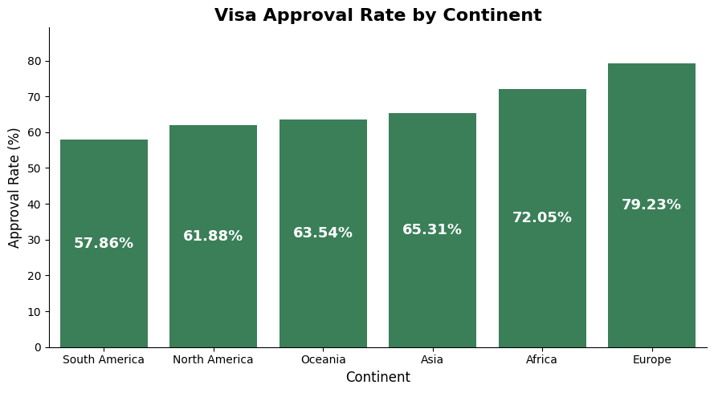

```python
# Calculate approval rate per continent
continent_approval = (
    data.groupby("continent")["case_status"]
    .mean()
    .sort_values()
    * 100
).round(2)

# Plot
plt.figure(figsize=(9,5))
ax = sns.barplot(
    x=continent_approval.index,
    y=continent_approval.values,
    color="#2E8B57"
)

# Add centered labels
for i, value in enumerate(continent_approval.values):
    ax.text(
        i,
        value / 2,
        f"{value}%",
        ha="center",
        va="center",
        fontsize=13,
        fontweight="bold",
        color="white"
    )

plt.title("Visa Approval Rate by Continent", fontsize=16, weight="bold")
plt.xlabel("Continent", fontsize=12)
plt.ylabel("Approval Rate (%)", fontsize=12)

sns.despine()
plt.ylim(0, continent_approval.max() + 10)
plt.tight_layout()
plt.show()
```

**Observations**

- Visa approval rates vary substantially across continents. South America has the lowest approval rate at 57.86%, followed by North America (61.88%), Oceania (63.54%), and Asia (65.31%).
- Approval rates are noticeably higher for Africa at 72.05%, with Europe having the highest approval rate at 79.23%.

### Additional EDA

#### Correlation Among Numerical Variables

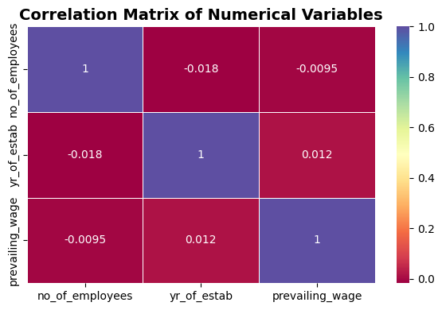

```python
numeric_cols = ['no_of_employees', 'yr_of_estab', 'prevailing_wage']

plt.figure(figsize=(6,4))
sns.heatmap(data[numeric_cols].corr(), annot=True, cmap="Spectral", linewidths=0.5)
plt.title("Correlation Matrix of Numerical Variables", fontsize=14, weight='bold')
plt.tight_layout()
plt.show()
```

**Observations**

The numerical variables in the dataset show extremely low correlation with one another.

- no_of_employees vs. yr_of_estab: –0.018
- no_of_employees vs. prevailing_wage: –0.0095
- yr_of_estab vs. prevailing_wage: 0.012

#### Boxplot Numerical Variables

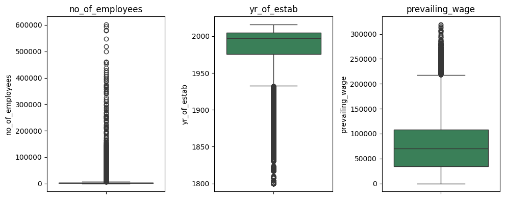

```python
plt.figure(figsize=(10,4))
for i, col in enumerate(numeric_cols):
    plt.subplot(1, 3, i+1)
    sns.boxplot(y=data[col], color="#2E8B57")
    plt.title(col)
plt.tight_layout()
plt.show()
```

**Observations**

- no_of_employees shows a very wide range with extreme high-end values, reflecting the presence of very large corporations alongside small businesses. These outliers are expected in real-world company-size distributions and represent true variation rather than errors.
- yr_of_estab displays outliers on the lower end, representing older companies founded in the 1800s and early 1900s. These values are valid historically and indicate a long tail of older organizations.
- prevailing_wage also shows substantial high-end outliers, likely driven by specialized occupations or high-skill positions with significantly above-average wage levels. These outliers are realistic and reflect true economic variability.

#### Distribution of Categorical Variables (Frequency)

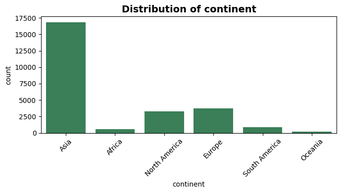

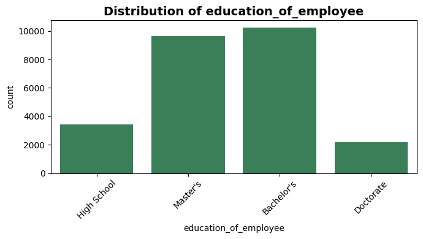

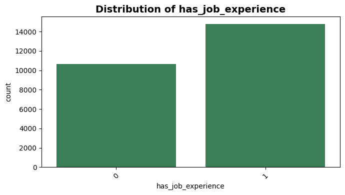

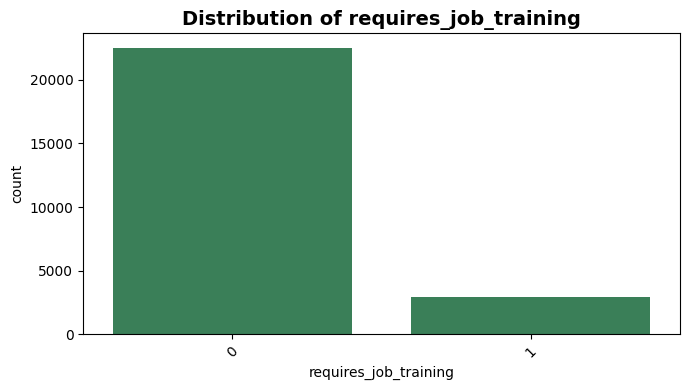

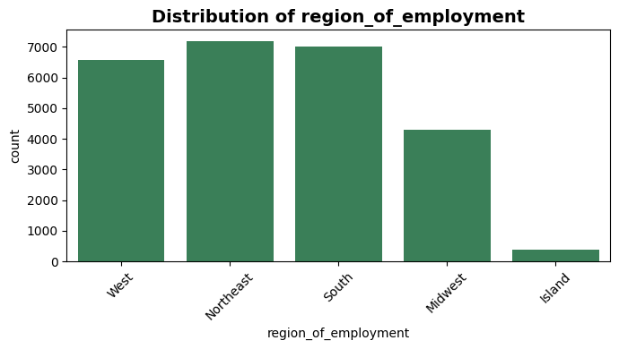

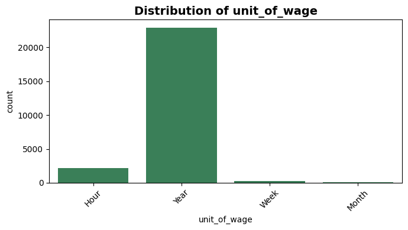

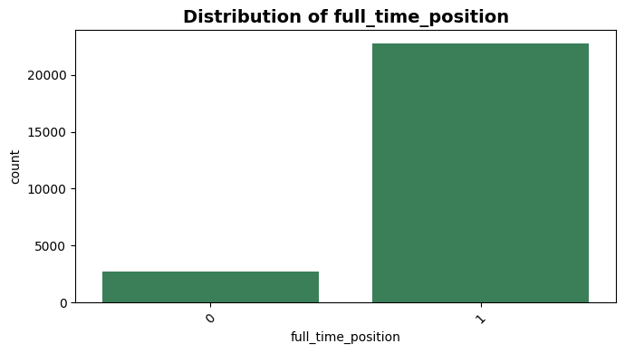

```python
cat_cols = ['continent', 'education_of_employee', 'has_job_experience',
            'requires_job_training', 'region_of_employment',
            'unit_of_wage', 'full_time_position']

for col in cat_cols:
    plt.figure(figsize=(7,4))
    sns.countplot(x=col, data=data, color="#2E8B57")
    plt.title(f"Distribution of {col}", fontsize=14, weight='bold')
    plt.xlabel(col)
    plt.xticks(rotation=45)
    plt.tight_layout()
    plt.show()
```

**Observations**

- Continent: Asia accounts for the overwhelming majority of applicants, while Africa and Oceania contribute very few, showing strong geographic imbalance in the dataset.
- Education Level: Most applicants hold Bachelor's or Master's degrees, with High School and Doctorate categories being much smaller, indicating an education level skew toward advanced degrees.
- Job Experience: Slightly more applicants have prior job experience than not, providing a relatively balanced distribution that can be useful for modeling.
- Requires Job Training: The vast majority of applicants do not require job training, making this variable highly imbalanced with limited variability.
- Region of Employment: West, Northeast, and South dominate the dataset, while Island regions have very few records, suggesting uneven regional representation.
- Unit of Wage: Annual wage reporting is by far the most common, with hourly wages moderately represented and weekly/monthly wages being rare—supporting the need for wage standardization.
- Full-Time Position: Most positions are full-time, with part-time roles representing a small minority, which may influence approval outcomes given employer investment.

#### Pairwise Relationships Among Numerical Variables and Visa Approval

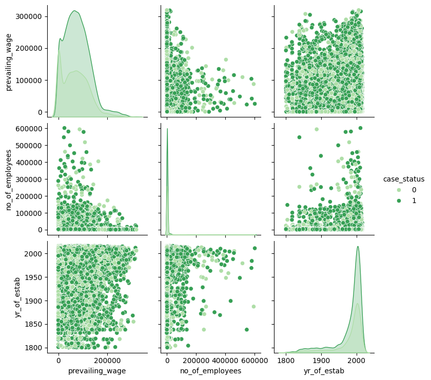

```python
sns.pairplot(data[['prevailing_wage', 'no_of_employees', 'yr_of_estab', 'case_status']],
             hue='case_status', diag_kind='kde', palette="Greens")
plt.show()
```

**Observations**

The pairplot shows no clear visual separation between approved and denied visa cases across any of the numerical variables. Both groups overlap heavily in the scatter plots for prevailing_wage, no_of_employees, and yr_of_estab, indicating that none of these features alone can distinguish approval outcomes.

The diagonal distributions further support this:

- prevailing_wage is right-skewed with most values concentrated at lower wage levels.
- no_of_employees is extremely skewed, with most companies being small and a long tail of very large employers.
- yr_of_estab shows a strong cluster around more recently established companies.

Overall, the pairplot suggests that visa approval decisions are influenced by combinations of variables rather than any single numerical factor.

# **Data Pre-processing**

#### Missing value treatment (if needed)

```python
missing_values = data.isnull().sum()
missing_values
```

|  | 0 |
| --- | --- |
| continent | 0 |
| education_of_employee | 0 |
| has_job_experience | 0 |
| requires_job_training | 0 |
| no_of_employees | 0 |
| yr_of_estab | 0 |
| region_of_employment | 0 |
| prevailing_wage | 0 |
| unit_of_wage | 0 |
| full_time_position | 0 |
| case_status | 0 |
| wage_bin | 0 |
| employee_bin | 0 |

**dtype:** int64

**Observations**

- There are no missing values in the dataset.

#### Treating Negative Employee Count

```python
# Fix negative employee counts
data['no_of_employees'] = data['no_of_employees'].abs()
```

### Feature engineering (if needed)

```python
# 1. Convert prevailing wage into annual wage
def convert_to_annual_wage(row):
    if row['unit_of_wage'] == 'Hour':
        return row['prevailing_wage'] * 2080   # 40 hrs/week × 52 weeks
    elif row['unit_of_wage'] == 'Week':
        return row['prevailing_wage'] * 52
    elif row['unit_of_wage'] == 'Month':
        return row['prevailing_wage'] * 12
    else:  # 'Year'
        return row['prevailing_wage']

data['annual_wage'] = data.apply(convert_to_annual_wage, axis=1)

# 2. Create company age

data['company_age'] = 2016 - data['yr_of_estab']

# 3. Log-transform skewed features

data['annual_wage_log'] = np.log1p(data['annual_wage'])
data['employees_log'] = np.log1p(data['no_of_employees'])

data.head()
```

|  | continent | education_of_employee | has_job_experience | requires_job_training | no_of_employees | yr_of_estab | region_of_employment | prevailing_wage | unit_of_wage | full_time_position | case_status | wage_bin | employee_bin | annual_wage | company_age | annual_wage_log | employees_log |
| --- | --- | --- | --- | --- | --- | --- | --- | --- | --- | --- | --- | --- | --- | --- | --- | --- | --- |
| 0 | Asia | High School | 0 | 0 | 14513 | 2007 | West | 592.2029 | Hour | 1 | 0 | Low Wage | Large | 1231782.032 | 9 | 14.023973 | 9.582869 |
| 1 | Asia | Master's | 1 | 0 | 2412 | 2002 | Northeast | 83425.6500 | Year | 1 | 1 | Upper-Mid Wage | Medium–Large | 83425.650 | 14 | 11.331723 | 7.788626 |
| 2 | Asia | Bachelor's | 0 | 1 | 44444 | 2008 | West | 122996.8600 | Year | 1 | 0 | High Wage | Large | 122996.860 | 8 | 11.719922 | 10.702008 |
| 3 | Asia | Bachelor's | 0 | 0 | 98 | 1897 | West | 83434.0300 | Year | 1 | 0 | Upper-Mid Wage | Small | 83434.030 | 119 | 11.331824 | 4.595120 |
| 4 | Africa | Master's | 1 | 0 | 1082 | 2005 | South | 149907.3900 | Year | 1 | 1 | High Wage | Small–Medium | 149907.390 | 11 | 11.917780 | 6.987490 |

### Outlier detection and treatment (if needed)

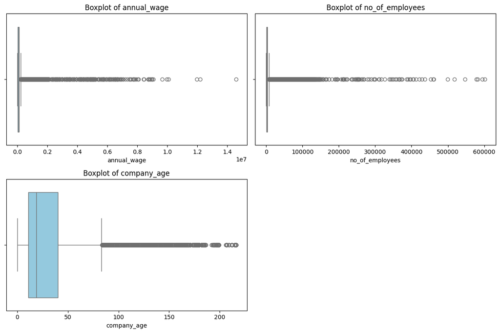

```python
numeric_cols = ['annual_wage', 'no_of_employees', 'company_age']

plt.figure(figsize=(12, 8))
for i, col in enumerate(numeric_cols, 1):
    plt.subplot(2, 2, i)
    sns.boxplot(x=data[col], color="skyblue")
    plt.title(f"Boxplot of {col}")

plt.tight_layout()
plt.show()
```

**Observations**

### Preparing data for modeling

```python
X = data.drop('case_status', axis=1)
y = data['case_status']
```

```python
X_train, X_test, y_train, y_test = train_test_split(X, y, test_size=0.25, random_state=42, stratify=y)
print(X_train.shape, X_test.shape)
```

```
(19110, 16) (6370, 16)
```

```python
y_test.value_counts(1)
```

| case_status | proportion |
| --- | --- |
| 1 | 0.667818 |
| 0 | 0.332182 |

**dtype:** float64

# **Model Building**

### Model Evaluation Criterion

The goal of this project is to predict whether a visa application will be approved (1) or denied (0).

**The model can make two kinds of incorrect predictions:**

1. False Positive (Type I Error)
   - Predicting Approved when the actual outcome is Denied.
2. False Negative (Type II Error)
   - Predicting Denied when the actual outcome is Approved.

**Which Error Is More Critical?**

While both errors carry consequences, False Positives are more harmful because they directly impact:

- Immigration compliance
- Hiring timelines
- Operational planning
- Financial risk

Thus, the model must carefully avoid incorrectly approving cases that would be denied.

**What Metric Should We Optimize?**

The dataset shows a moderate class imbalance (~67% approved vs. ~33% denied), meaning accuracy alone is misleading so we should optimize F1-Score

**Defining function to provide metric scores on the train and test set and a function to show confusion matrix.**

```python
def get_metrics(model, X_train, X_test, y_train, y_test):
    y_pred_train = model.predict(X_train)
    y_pred_test  = model.predict(X_test)
    y_pred_prob  = model.predict_proba(X_test)[:, 1]

    metrics = {
        "Accuracy (Train)": accuracy_score(y_train, y_pred_train),
        "Accuracy (Test)": accuracy_score(y_test, y_pred_test),
        "Precision": precision_score(y_test, y_pred_test),
        "Recall": recall_score(y_test, y_pred_test),
        "F1-Score": f1_score(y_test, y_pred_test),
        "ROC-AUC": roc_auc_score(y_test, y_pred_prob)
    }
    return metrics
```

```python
def plot_conf_matrix(model, X_test, y_test):
    y_pred = model.predict(X_test)
    cm = confusion_matrix(y_test, y_pred)

    sns.heatmap(cm, annot=True, fmt='d', cmap='Blues')
    plt.xlabel("Predicted")
    plt.ylabel("Actual")
    plt.title("Confusion Matrix")
    plt.show()
```

```python
categorical_cols = [
    'continent',
    'education_of_employee',
    'region_of_employment',
    'unit_of_wage',
    'full_time_position',
    'has_job_experience',
    'requires_job_training'
]

numeric_cols = [
    'annual_wage',
    'no_of_employees',
    'company_age'
]

processor = ColumnTransformer(
    transformers=[
        ("cat", OneHotEncoder(handle_unknown="ignore"), categorical_cols),
        ("num", "passthrough", numeric_cols)
    ]
)
```

```python
def model_performance_classification_sklearn(model, predictors, target):
    """
    Function to compute different metrics to check classification model performance
    """
    pred = model.predict(predictors)

    acc = accuracy_score(target, pred)
    recall = recall_score(target, pred)
    precision = precision_score(target, pred)
    f1 = f1_score(target, pred)

    df_perf = pd.DataFrame(
        {
            "Accuracy": acc,
            "Recall": recall,
            "Precision": precision,
            "F1": f1,
        },
        index=[0],
    )
    return df_perf
```

```python
def confusion_matrix_sklearn(model, predictors, target):
    """
    To plot the confusion_matrix with percentages
    """
    y_pred = model.predict(predictors)
    cm = confusion_matrix(target, y_pred)

    labels = np.asarray(
        [
            ["{0:0.0f}".format(item) + "\n{0:.2%}".format(item / cm.flatten().sum())]
            for item in cm.flatten()
        ]
    ).reshape(2, 2)

    plt.figure(figsize=(6, 4))
    sns.heatmap(cm, annot=labels, fmt="")
    plt.ylabel("True label")
    plt.xlabel("Predicted label")
```

### Decision Tree

```
   Accuracy  Recall  Precision   F1
0       1.0     1.0        1.0  1.0
   Accuracy    Recall  Precision        F1
0  0.651805  0.735073   0.741347  0.738196
```

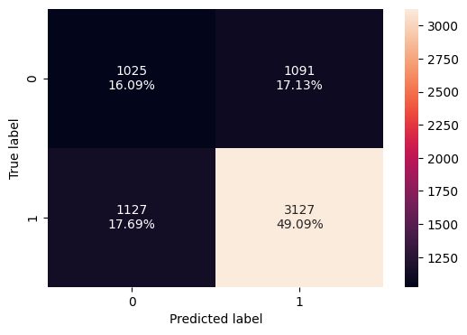

```python
dt_model = Pipeline(steps=[
    ('preprocess', processor),
    ('clf', DecisionTreeClassifier(random_state=42))
])

dt_model.fit(X_train, y_train)

# Training performance
dt_train_perf = model_performance_classification_sklearn(dt_model, X_train, y_train)
print(dt_train_perf)

# Testing performance
dt_test_perf = model_performance_classification_sklearn(dt_model, X_test, y_test)
print(dt_test_perf)

# Confusion matrix
confusion_matrix_sklearn(dt_model, X_test, y_test)
```

**Observations**

- The decision tree is overfitting the training data.

### Random Forest Classifier

```
Training Performance:
    Accuracy  Recall  Precision   F1
0       1.0     1.0        1.0  1.0

Testing Performance:
    Accuracy    Recall  Precision        F1
0  0.716954  0.829337   0.766124  0.796478

Confusion Matrix:
```

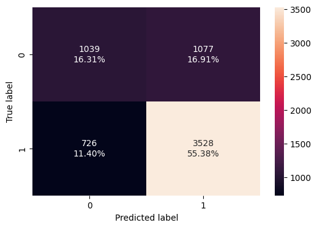

```python
# 1. Define the Random Forest model in a Pipeline
rf_model = Pipeline(steps=[
    ('preprocess', processor),   # your ColumnTransformer
    ('clf', RandomForestClassifier(
        random_state=42,
        n_estimators=100,        # default, can tune later
        max_depth=None,
        class_weight=None        # important for imbalanced data
    ))
])

# 2. Fit the model
rf_model.fit(X_train, y_train)

# 3. Training performance
rf_train_perf = model_performance_classification_sklearn(rf_model, X_train, y_train)
print("Training Performance:\n", rf_train_perf, "\n")

# 4. Testing performance
rf_test_perf = model_performance_classification_sklearn(rf_model, X_test, y_test)
print("Testing Performance:\n", rf_test_perf, "\n")

# 5. Confusion Matrix
print("Confusion Matrix:")
confusion_matrix_sklearn(rf_model, X_test, y_test)
```

**Observations**

- The random forest classifier is overfitting the training data

### Bagging Classifier

```
Training Performance:
    Accuracy  Recall  Precision   F1
0       1.0     1.0        1.0  1.0

Testing Performance:
    Accuracy    Recall  Precision        F1
0  0.716641  0.829572   0.765676  0.796344
```

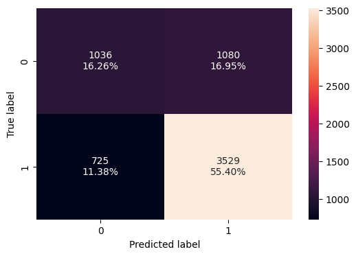

```python
# define the bag model in pipeline
bag_model = Pipeline(steps=[
    ('preprocess', processor),
    ('clf', BaggingClassifier(
        estimator=DecisionTreeClassifier(),
        n_estimators=100,
        random_state=42,
        max_samples=1.0,
        max_features=1.0,
        bootstrap=True
    ))
])

# Fit the model
bag_model.fit(X_train, y_train)

# Training performance
bag_train_perf = model_performance_classification_sklearn(bag_model, X_train, y_train)
print("Training Performance:\n", bag_train_perf, "\n")

# Testing performance
bag_test_perf = model_performance_classification_sklearn(bag_model, X_test, y_test)
print("Testing Performance:\n", bag_test_perf, "\n")

# Confusion matrix
confusion_matrix_sklearn(bag_model, X_test, y_test)
```

**Observations**

- The bagging classifier is overfitting the training data

### AdaBoost Classifier

```
Training Performance:
    Accuracy    Recall  Precision        F1
0  0.737938  0.889141   0.759537  0.819245
Testing Performance:
    Accuracy    Recall  Precision        F1
0  0.726845  0.884344   0.750898  0.812176
```

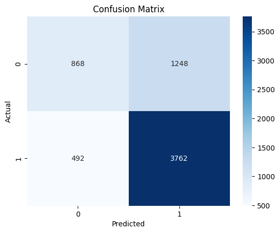

```python
# Define AdaBoost model
ada_model = Pipeline(steps=[
    ('preprocess', processor),
    ('clf', AdaBoostClassifier(
        n_estimators=100,
        learning_rate=1.0,
        random_state=1
    ))
])

# Fit model
ada_model.fit(X_train, y_train)

# Performance
print("Training Performance:\n", model_performance_classification_sklearn(ada_model, X_train, y_train))
print("Testing Performance:\n", model_performance_classification_sklearn(ada_model, X_test, y_test))

# Confusion matrix
plot_conf_matrix(ada_model, X_test, y_test)
```

**Observations**

- The model generalizes well. AdaBoost does not appear to be overfitting

### Gradient Boosting Classifier

```
Training Performance:
    Accuracy    Recall  Precision        F1
0  0.757405  0.875901   0.785554  0.828271
Testing Performance:
    Accuracy    Recall  Precision        F1
0  0.741758  0.870475   0.771941  0.818252
```

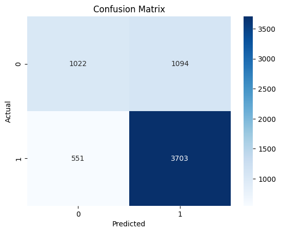

```python
gb_model = Pipeline(steps=[
    ('preprocess', processor),
    ('clf', GradientBoostingClassifier(
        n_estimators=100,
        learning_rate=0.1,
        max_depth=3,
        random_state=1
    ))
])

# Fit the model
gb_model.fit(X_train, y_train)

# Performance
print("Training Performance:\n", model_performance_classification_sklearn(gb_model, X_train, y_train))
print("Testing Performance:\n", model_performance_classification_sklearn(gb_model, X_test, y_test))

# Confusion Matrix
plot_conf_matrix(gb_model, X_test, y_test)
```

**Observations**

- Gradient Boosting generalizes very well (training vs testing nearly identical).

### XGBoost Classifier

```
Training Performance:
   Accuracy    Recall  Precision        F1
0  0.780586  0.892353   0.801605  0.844548

Testing Performance:
   Accuracy   Recall  Precision        F1
0  0.742543  0.87024    0.77286  0.818664
```

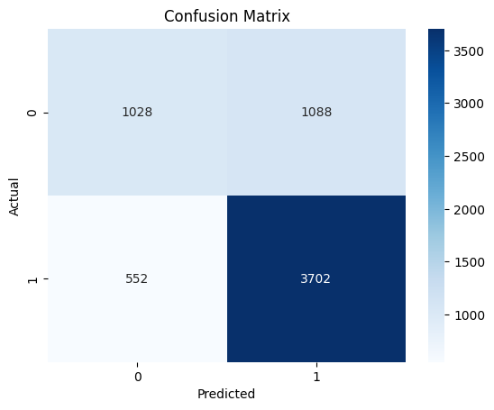

```python
# Define the model
xgb_clf = XGBClassifier(
    n_estimators=300,
    max_depth=5,
    learning_rate=0.05,
    subsample=0.8,
    colsample_bytree=0.8,
    objective="binary:logistic",
    eval_metric="logloss",
    n_jobs=-1,
    random_state=42
)

# Pipeline with preprocessing
xgb_model = Pipeline(steps=[
    ('preprocess', processor),
    ('clf', xgb_clf)
])

# Fit the model
xgb_model.fit(X_train, y_train)

# Evaluate performance
print("Training Performance:")
xgb_train_perf = model_performance_classification_sklearn(xgb_model, X_train, y_train)
print(xgb_train_perf)

print("\nTesting Performance:")
xgb_test_perf = model_performance_classification_sklearn(xgb_model, X_test, y_test)
print(xgb_test_perf)

# Confusion Matrix
plot_conf_matrix(xgb_model, X_test, y_test)
```

**Observations**

#### Model Building - Oversampled Data

```
===== Decision Tree (SMOTE) PERFORMANCE =====
Training Performance:
    Accuracy    Recall  Precision        F1
0  0.822117  0.878016   0.789726  0.831534
Testing Performance:
    Accuracy    Recall  Precision        F1
0   0.73281  0.853315   0.771028  0.810087
```

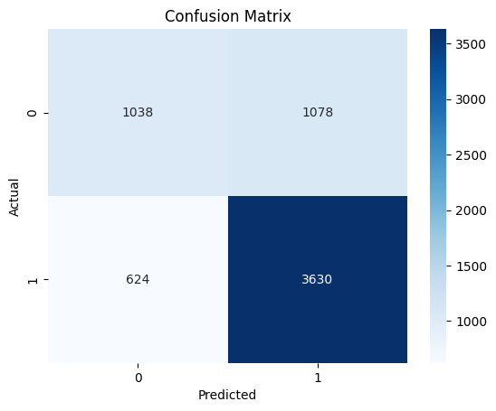

```
===== Random Forest (SMOTE) PERFORMANCE =====
Training Performance:
    Accuracy    Recall  Precision        F1
0  0.831597  0.881934   0.801267  0.839667
Testing Performance:
    Accuracy    Recall  Precision        F1
0  0.744113  0.859426   0.779863  0.817714
```

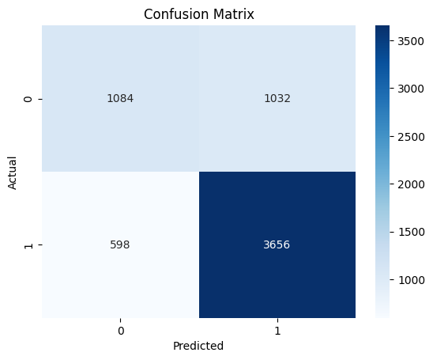

```
===== Bagging (SMOTE) PERFORMANCE =====
Training Performance:
    Accuracy    Recall  Precision        F1
0  0.825917  0.892824   0.787452  0.836834
Testing Performance:
    Accuracy    Recall  Precision        F1
0  0.738305  0.865773   0.770663  0.815454
```

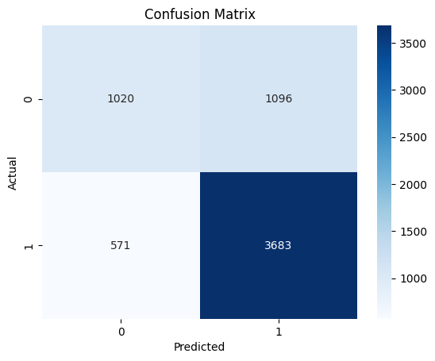

```
===== AdaBoost (SMOTE) PERFORMANCE =====
Training Performance:
    Accuracy    Recall  Precision        F1
0  0.767824  0.795754   0.753654  0.774132
Testing Performance:
    Accuracy    Recall  Precision        F1
0  0.707221  0.787729   0.776953  0.782304
```

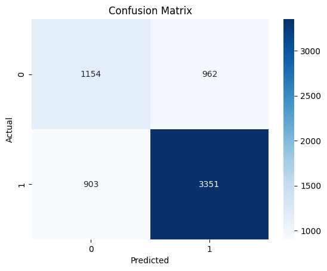

```
===== Gradient Boosting (SMOTE) PERFORMANCE =====
Training Performance:
    Accuracy    Recall  Precision        F1
0  0.811854  0.862582   0.783128  0.820937
Testing Performance:
    Accuracy    Recall  Precision        F1
0  0.740973  0.856606   0.777968  0.815395
```

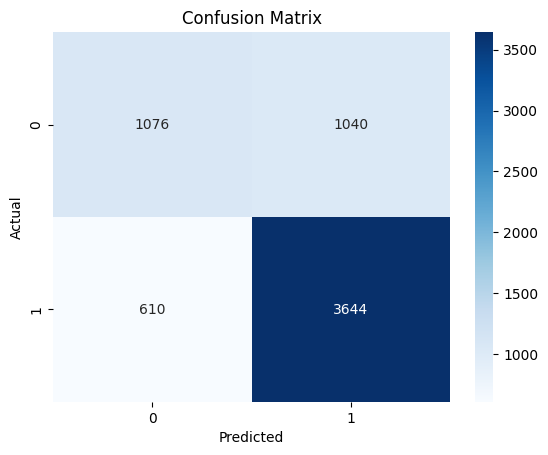

```
===== XGBoost (SMOTE) PERFORMANCE =====
Training Performance:
    Accuracy    Recall  Precision        F1
0  0.819962  0.872767   0.789399  0.828992
Testing Performance:
    Accuracy    Recall  Precision        F1
0  0.740973  0.862717   0.774916  0.816463
```

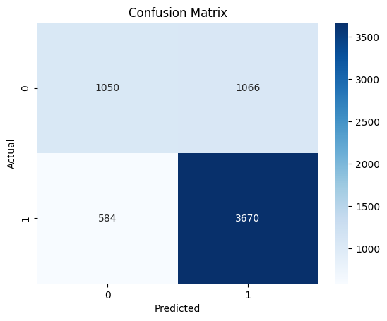

```python
# Preprocess features
X_train_prep = processor.fit_transform(X_train)
X_test_prep = processor.transform(X_test)

# Apply SMOTE
sm = SMOTE(random_state=1)
X_train_sm, y_train_sm = sm.fit_resample(X_train_prep, y_train)

# Evalualte models
def evaluate_model(name, model):
    model.fit(X_train_sm, y_train_sm)

    train_perf = model_performance_classification_sklearn(model, X_train_sm, y_train_sm)
    test_perf  = model_performance_classification_sklearn(model, X_test_prep, y_test)

    print(f"\n===== {name} PERFORMANCE =====")
    print("Training Performance:\n", train_perf)
    print("Testing Performance:\n", test_perf)
    plot_conf_matrix(model, X_test_prep, y_test)

# Fit models

evaluate_model("Decision Tree (SMOTE)", DecisionTreeClassifier(max_depth=10, random_state=1))
evaluate_model("Random Forest (SMOTE)", RandomForestClassifier(n_estimators=150, max_depth=12, random_state=1))
evaluate_model("Bagging (SMOTE)", BaggingClassifier(
    estimator=DecisionTreeClassifier(max_depth=10),
    n_estimators=80,
    random_state=1))
evaluate_model("AdaBoost (SMOTE)", AdaBoostClassifier(n_estimators=150, learning_rate=0.1, random_state=1))
evaluate_model("Gradient Boosting (SMOTE)", GradientBoostingClassifier(
    n_estimators=150, learning_rate=0.05, max_depth=3))
evaluate_model("XGBoost (SMOTE)", XGBClassifier(
    n_estimators=300, learning_rate=0.05, max_depth=4,
    eval_metric='logloss', random_state=1))
```

**Observations**